# Time Series Analysis in R

Andy Herzberg

09.07.2019

### Table of contents

- Exploratory Data Analysis
- Decomposition of the data
- Autocorrelations and choosing model order
- Fitting an ARIMA model
- Futher analysis and testing of our models
- Sources

### Exploratory data analysis

back to top

At first we need to install and load all required libraries.

```r
# install.packages("rio")
library("ggplot2")
library("forecast")
library("tseries")
#library("tidyverse")
#library("rio")
#library("xts")
library("dplyr")
#library("readxl") #in case we need to load an Excel file
```

The data for this analysis of the Air Quality Index can be downloaded here: https://www.epa.gov/outdoor-air-quality-data/download-daily-data.

```r
#Load the data
data1 <- read.csv("ad_viz_plotval_data.csv")
head(data1, 3)
```

|  | Date | Source | Site.ID | POC | Daily.Max.1.hour.SO2.Concentration | UNITS | DAILY_AQI_VALUE | Site.Name | DAILY_OBS_COUNT | PERCENT_COMPLETE | AQS_PARAMETER_CODE | AQS_PARAMETER_DESC | CBSA_CODE | CBSA_NAME | STATE_CODE | STATE | COUNTY_CODE | COUNTY | SITE_LATITUDE | SITE_LONGITUDE |
| --- | --- | --- | --- | --- | --- | --- | --- | --- | --- | --- | --- | --- | --- | --- | --- | --- | --- | --- | --- | --- |
| 1 | 01/01/2018 | AQS | 60371103 | 9 | 0.9 | ppb | 0 | Los Angeles-North Main Street | 24 | 100 | 42401 | Sulfur dioxide | 31080 | Los Angeles-Long Beach-Anaheim, CA | 6 | California | 37 | Los Angeles | 34.06659 | -118.2269 |
| 2 | 01/02/2018 | AQS | 60371103 | 9 | 1.2 | ppb | 1 | Los Angeles-North Main Street | 24 | 100 | 42401 | Sulfur dioxide | 31080 | Los Angeles-Long Beach-Anaheim, CA | 6 | California | 37 | Los Angeles | 34.06659 | -118.2269 |
| 3 | 01/03/2018 | AQS | 60371103 | 9 | 1.0 | ppb | 1 | Los Angeles-North Main Street | 24 | 100 | 42401 | Sulfur dioxide | 31080 | Los Angeles-Long Beach-Anaheim, CA | 6 | California | 37 | Los Angeles | 34.06659 | -118.2269 |

The Date column needs to be converted to date type.

```r
data1$DATES <- as.Date(data1$Date, "%m/%d/%Y")
data1$Month <- format(data1$DATES,"%m")
tail(data1, 3)
```

|  | Date | Source | Site.ID | POC | Daily.Max.1.hour.SO2.Concentration | UNITS | DAILY_AQI_VALUE | Site.Name | DAILY_OBS_COUNT | PERCENT_COMPLETE | AQS_PARAMETER_CODE | AQS_PARAMETER_DESC | CBSA_CODE | CBSA_NAME | STATE_CODE | STATE | COUNTY_CODE | COUNTY | SITE_LATITUDE | SITE_LONGITUDE | DATES | Month |
| --- | --- | --- | --- | --- | --- | --- | --- | --- | --- | --- | --- | --- | --- | --- | --- | --- | --- | --- | --- | --- | --- | --- |
| 1065 | 12/29/2018 | AQS | 60375005 | 1 | 1.7 | ppb | 1 | LAX Hastings | 24 | 100 | 42401 | Sulfur dioxide | 31080 | Los Angeles-Long Beach-Anaheim, CA | 6 | California | 37 | Los Angeles | 33.95507 | -118.4305 | 2018-12-29 | 12 |
| 1066 | 12/30/2018 | AQS | 60375005 | 1 | 4.3 | ppb | 6 | LAX Hastings | 24 | 100 | 42401 | Sulfur dioxide | 31080 | Los Angeles-Long Beach-Anaheim, CA | 6 | California | 37 | Los Angeles | 33.95507 | -118.4305 | 2018-12-30 | 12 |
| 1067 | 12/31/2018 | AQS | 60375005 | 1 | 0.8 | ppb | 0 | LAX Hastings | 24 | 100 | 42401 | Sulfur dioxide | 31080 | Los Angeles-Long Beach-Anaheim, CA | 6 | California | 37 | Los Angeles | 33.95507 | -118.4305 | 2018-12-31 | 12 |

Do some cleaning in order to keep only the relevant data bits.

```r
data1$SO2 <- data1$Daily.Max.1.hour.SO2.Concentration
data1 <- select(data1, DATES, SO2, Month)
head(data1, 3)
```

|  | DATES | SO2 | Month |
| --- | --- | --- | --- |
| 1 | 2018-01-01 | 0.9 | 01 |
| 2 | 2018-01-02 | 1.2 | 01 |
| 3 | 2018-01-03 | 1.0 | 01 |

Inspect the SO2 column.

```r
summary(data1$SO2)
```

```
##    Min. 1st Qu.  Median    Mean 3rd Qu.    Max.
##  -0.400   0.700   1.100   1.639   2.100  17.900
```

Draw a histogram f the SO2 data.

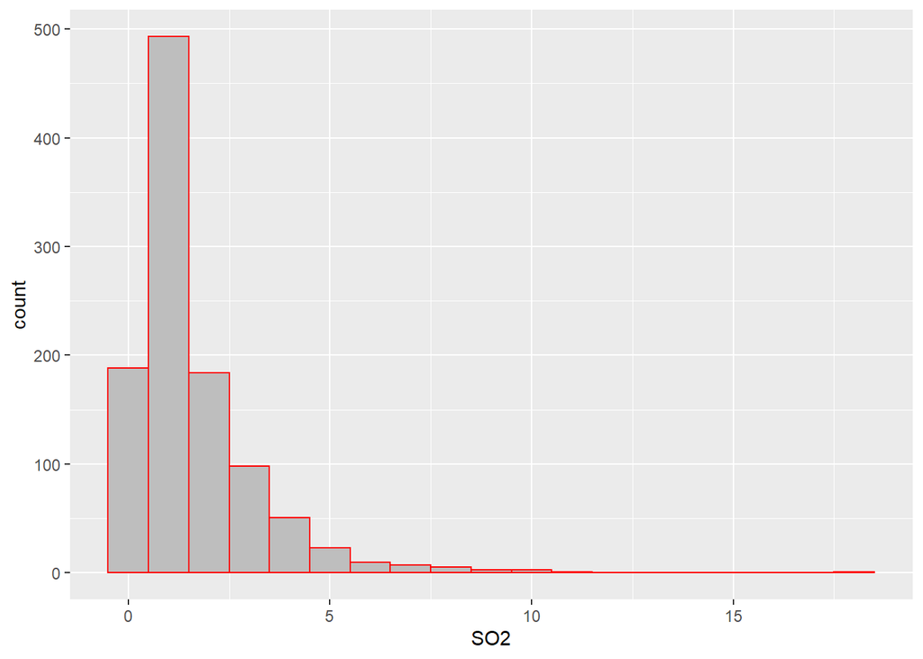

```r
ggplot(data1, aes(x=SO2)) +
  geom_histogram(binwidth = 1, colour = "red", fill = "grey")
```

Plot the SO2 field over time - shows high variance in this case.

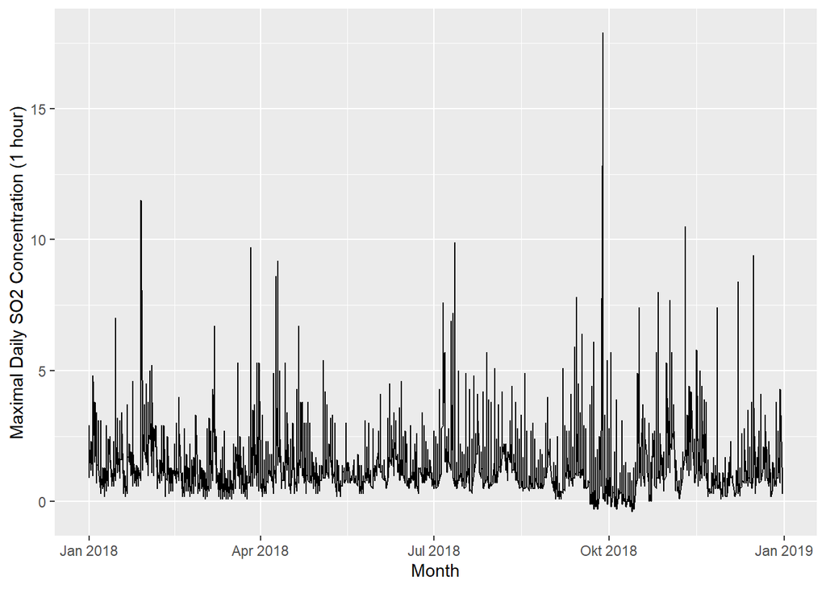

```r
ggplot(data1, aes(DATES, SO2)) +
  geom_line() +
  scale_x_date('Month') +
  ylab("Maximal Daily SO2 Concentration (1 hour)") +
  xlab("")
```

PLot month over month in order to see the ranges and outliers.

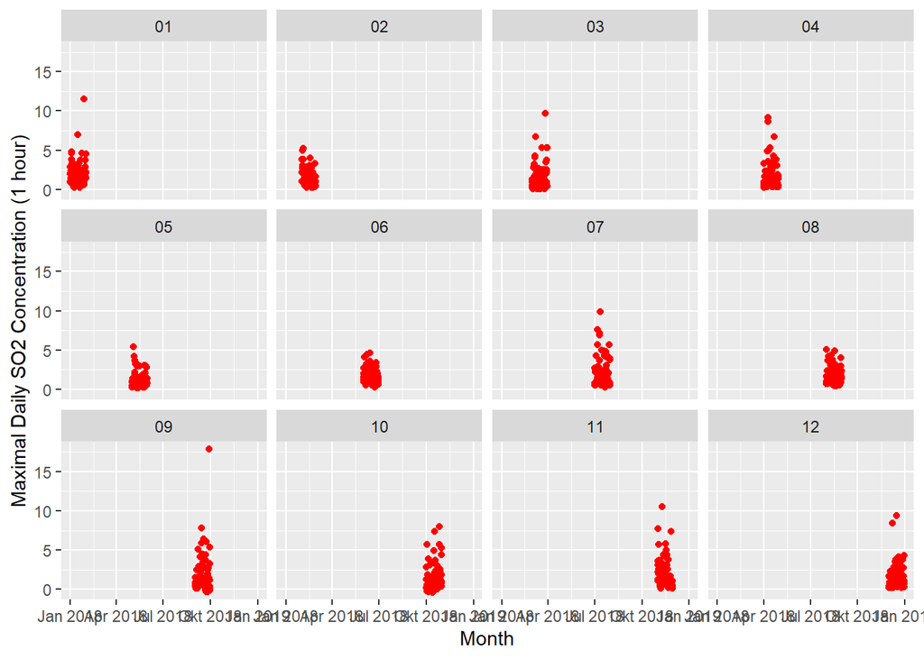

```r
ggplot(data1, aes(DATES, SO2)) +
  geom_point(color = "red") +
  facet_wrap(~ Month) +
  scale_x_date('Month') +
  ylab("Maximal Daily SO2 Concentration (1 hour)") +
  xlab("")
```

Create a time series object based on S02 to pass to tsclean().

```r
count_TSObject <- ts(data1[,c('SO2')])
data1$clean_count = tsclean(count_TSObject)
```

Graph clean data - ignore type ts scale warning. Plot original data (blue) by the side for caomparison

.

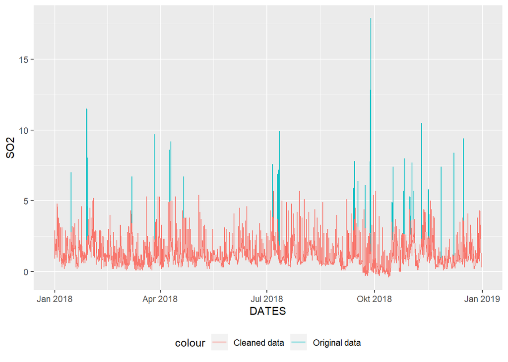

```r
 ggplot() +
  geom_line(data=data1, aes(x=DATES, y=SO2, color="Original data")) +
  geom_line(data=data1, aes(x=DATES, y=clean_count, color="Cleaned data")) +
  theme(legend.position="bottom")
```

Get weekly and monthly moving averages (MA) and compare to cleaned daily datawhich still has a lot variance and volatility in it.

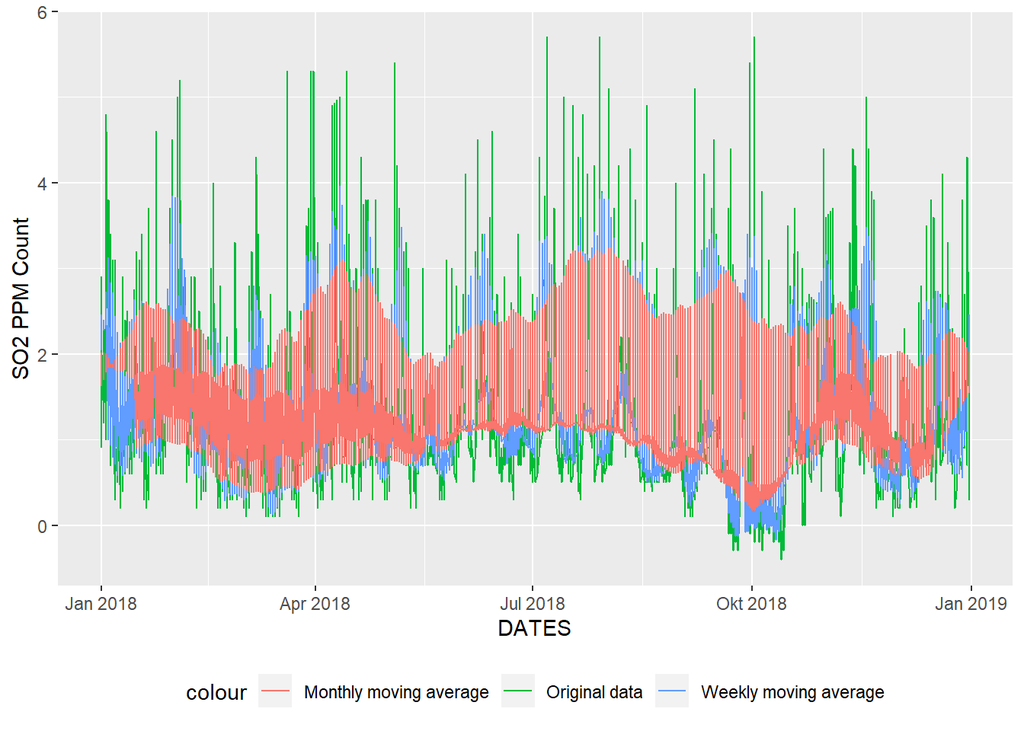

```r
data1$cnt_ma <- ma(data1$clean_count, order=7) # using the clean count with no outliers
data1$cnt_ma30 <- ma(data1$clean_count, order=30)
ggplot() +
  geom_line(data=data1, aes(x=DATES, y=clean_count, color ="Original data")) +
  geom_line(data=data1, aes(x=DATES, y=cnt_ma, color ="Weekly moving average")) +
  geom_line(data=data1, aes(x=DATES, y=cnt_ma30, color ="Monthly moving average")) +
  ylab("SO2 PPM Count") +
  theme(legend.position="bottom")
```

## Decomposition of the data

back to top

Take seasonality, trend and cycle into account Calculate seasonal component with stl().

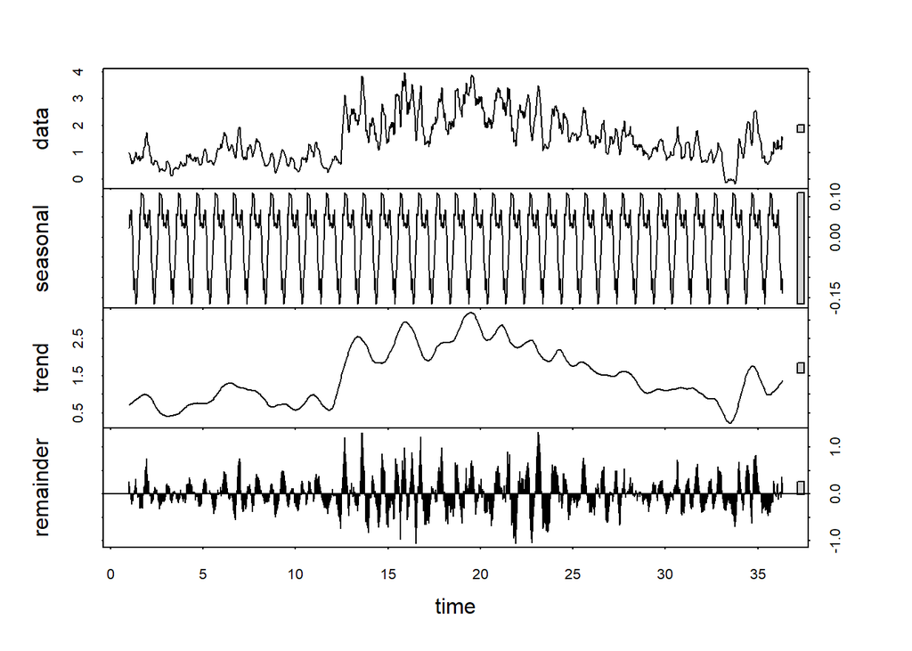

```r
count_ma <- ts(na.omit(data1$cnt_ma), frequency=30)
decomp = stl(count_ma, s.window = "periodic")
deseasonal_cnt = seasadj(decomp)
plot(decomp)
```

Test for stationarity - first visual check for stationarity variance 2nd - Augmented Dickey-Fuller test.

```r
adf.test(count_ma, alternative="stationary")
```

```
##
##  Augmented Dickey-Fuller Test
##
## data:  count_ma
## Dickey-Fuller = -3.348, Lag order = 10, p-value = 0.0624
## alternative hypothesis: stationary
```

## Autocorrelations and choosing model order

back to top

ACF plots display correlations between a series and its lags.

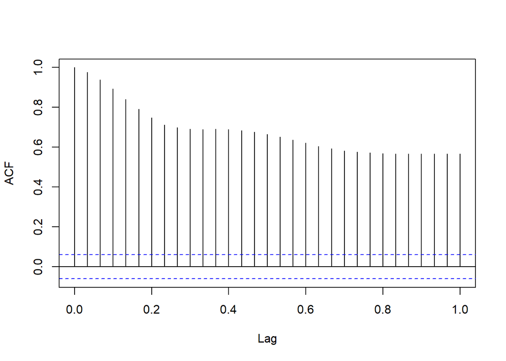

```r
acf(count_ma, main="")
```

PACF plots display correlation between a series and its lags that explained by previous lags.

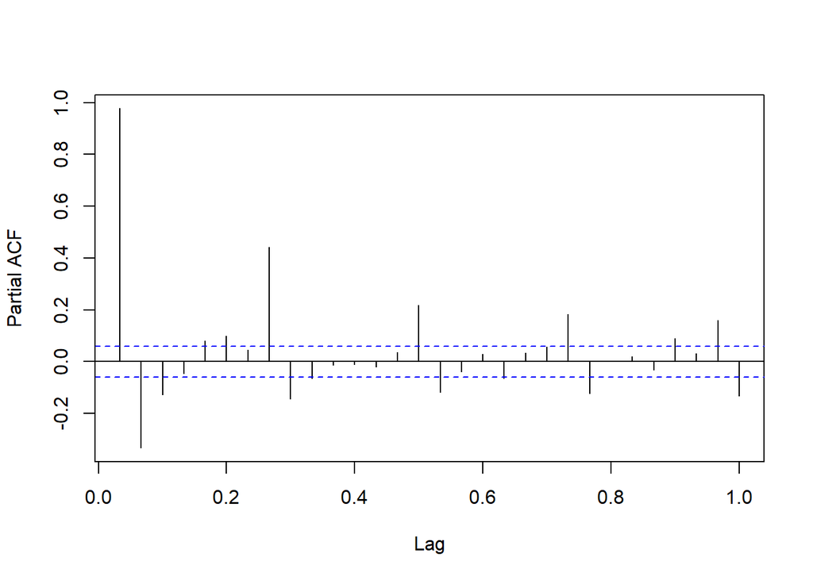

```r
pacf(count_ma, main="")
```

Difference of 1 is sufficient

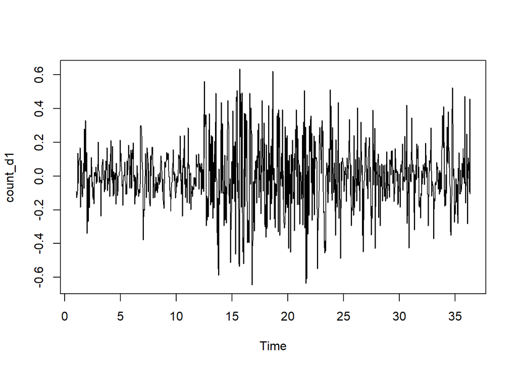

```r
count_d1 = diff(deseasonal_cnt, differences = 1)
plot(count_d1)
```

```r
adf.test(count_d1, alternative="stationary")
```

```
##
##  Augmented Dickey-Fuller Test
##
## data:  count_d1
## Dickey-Fuller = -11.532, Lag order = 10, p-value = 0.01
## alternative hypothesis: stationary
```

Look for spikes at specific lag points of the differenced series (using count_d1 from above)

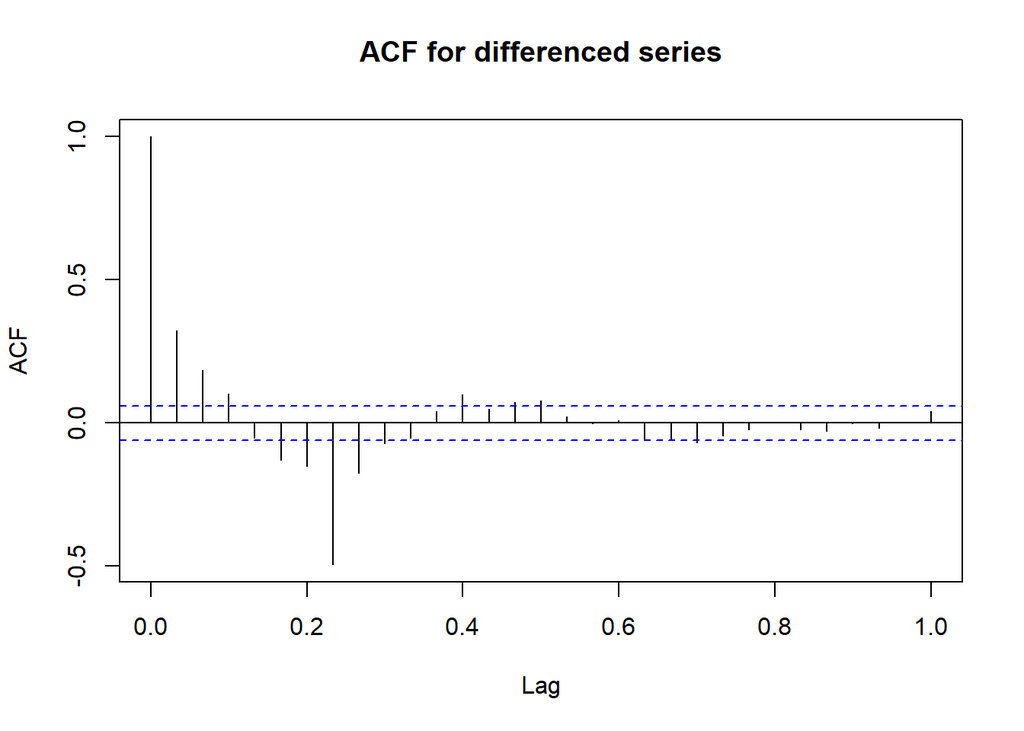

```r
acf(count_d1, main = "ACF for differenced series")
```

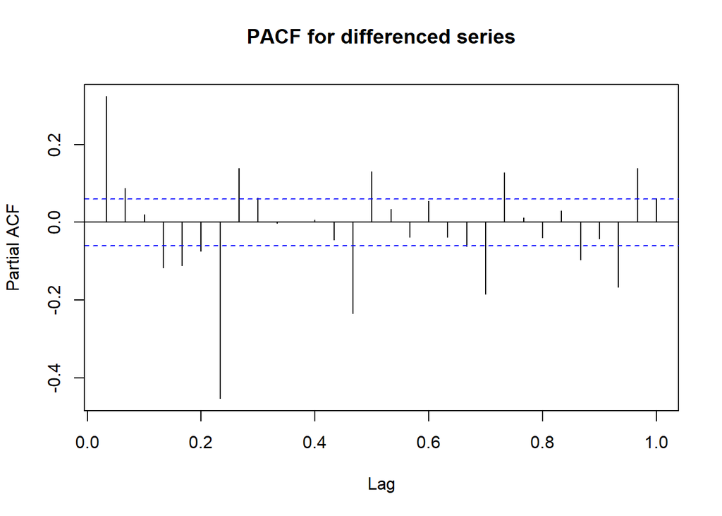

```r
pacf(count_d1, main = "PACF for differenced series")
```

## Fitting an ARIMA model

back to top

Get auto fit p, d, q values for AR(p) I(d) MA(q)

```r
auto.arima(deseasonal_cnt, seasonal=FALSE)
```

```
## Series: deseasonal_cnt
## ARIMA(2,1,2)
##
## Coefficients:
##          ar1      ar2      ma1     ma2
##       1.6753  -0.8644  -1.4434  0.6467
## s.e.  0.0333   0.0263   0.0426  0.0460
##
## sigma^2 estimated as 0.02728:  log likelihood=406.56
## AIC=-803.12   AICc=-803.07   BIC=-778.29
```

Evaluate and iterate: Does the model make sense?

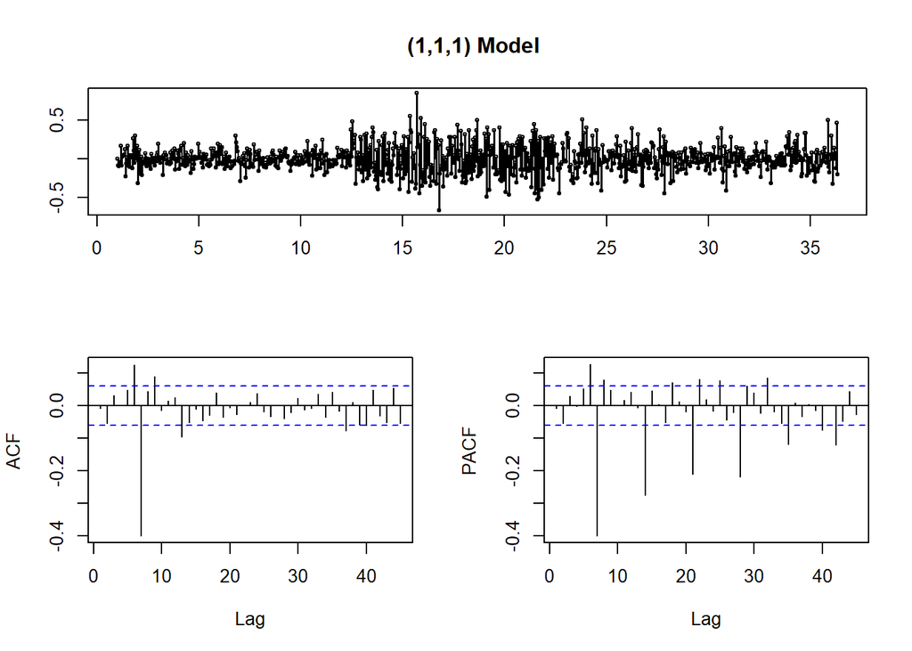

```r
fit <- auto.arima(deseasonal_cnt, seasonal=FALSE) # same as above but fititng a model
tsdisplay(residuals(fit), lag.max = 45, main='(1,1,1) Model ')
```

Graph shows series lags at 7, so modify model for p or q = 7.

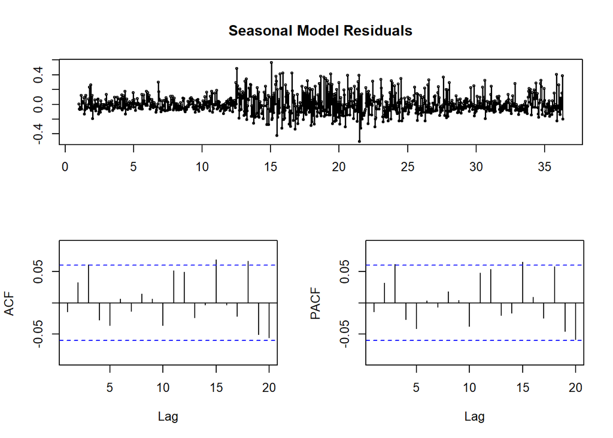

```r
fit2 <- arima(deseasonal_cnt, order=c(1,1,7))
tsdisplay(residuals(fit2), lag.max=20, main="Seasonal Model Residuals")
```

Forecast new fit model (fit2) for h=30 periods (30 days).

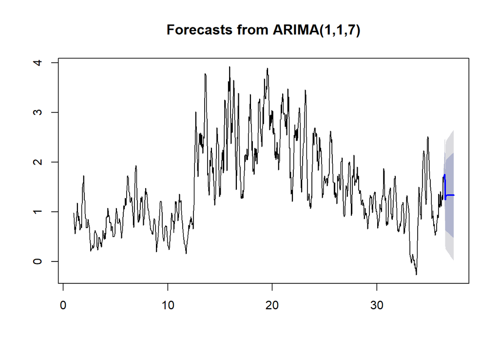

```r
fcast <- forecast(fit2, h=30)
plot(fcast)
```

### Test model performance with a holdout set

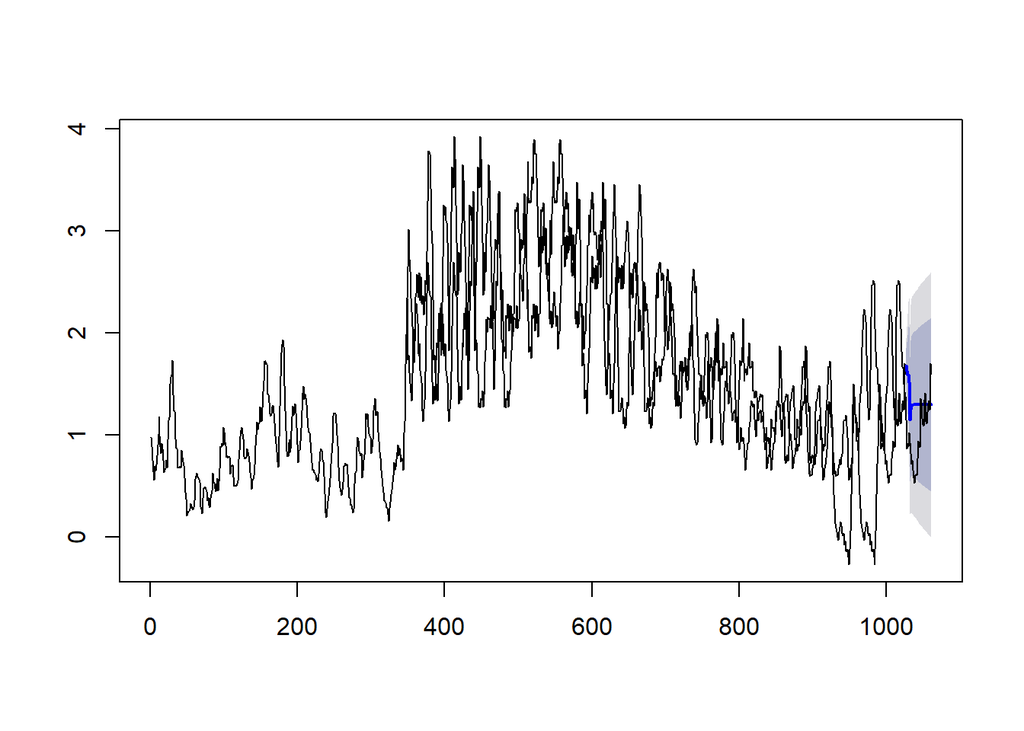

```r
hold <- window(ts(deseasonal_cnt), start(350))
fit_no_holdout = arima(deseasonal_cnt[-c(350:384)], order=c(1,1,7))
fcast_no_holdout <- forecast(fit_no_holdout, h=35)
plot(fcast_no_holdout, main="")
lines(ts(deseasonal_cnt))
```

Model needs seasonality added back in as it is too linear and not reality conform

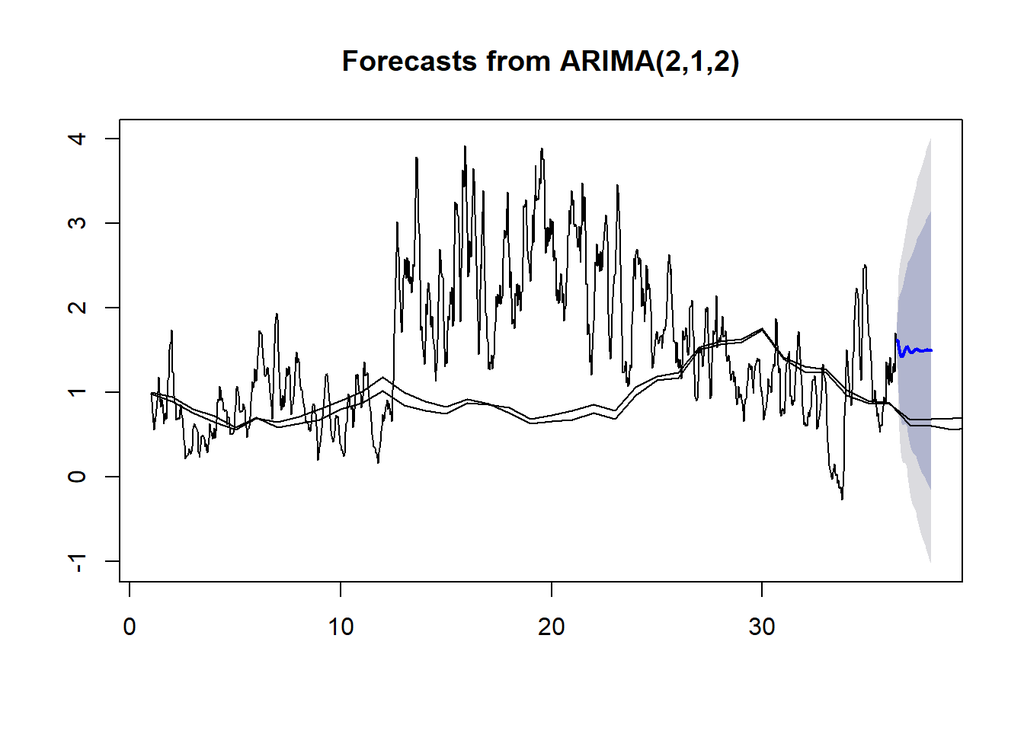

```r
fit_w_seasonality <- auto.arima(deseasonal_cnt, seasonal = TRUE)
seas_forecast <- forecast(fit_w_seasonality, h=50)
plot(seas_forecast)

lines(ts(count_ma))
lines(ts(deseasonal_cnt))
```

### Futher analysis and testing of our models

Test against original auto.arima() p, d, q values

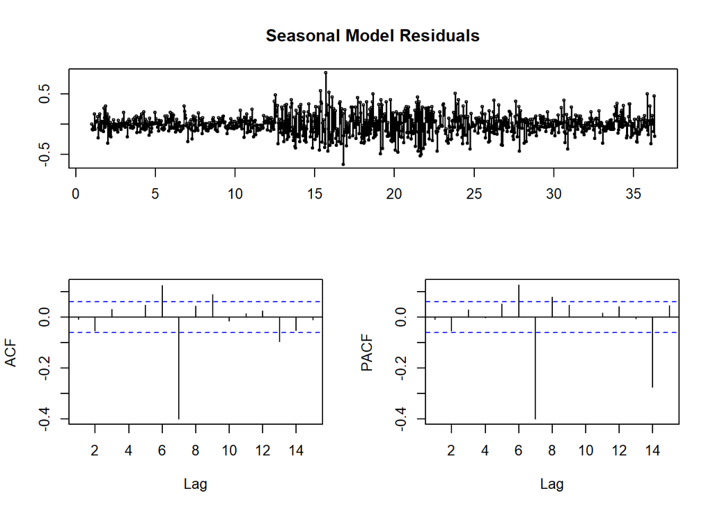

```r
fit3 <- auto.arima(deseasonal_cnt, seasonal=FALSE)
tsdisplay(residuals(fit3), lag.max=15, main ="Seasonal Model Residuals")
```

Evidence exists of a lag at 7, a higher order q value (q=7) might be necessary.

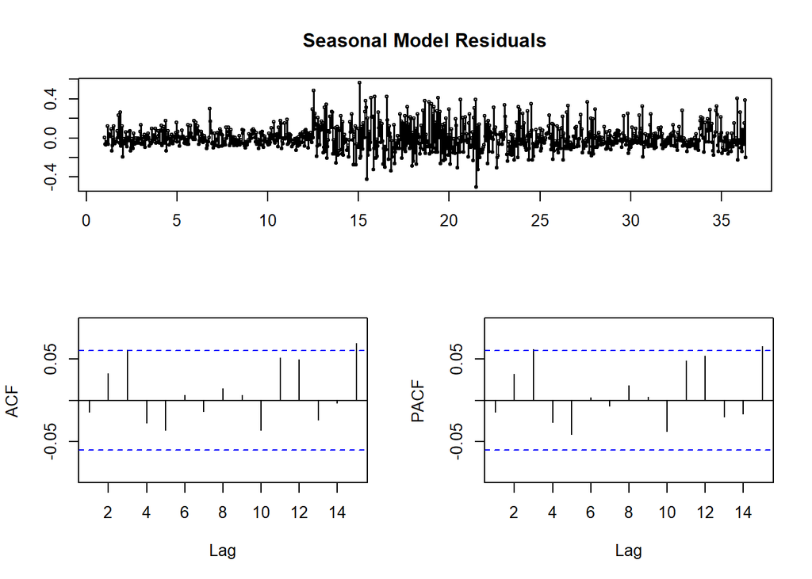

```r
fit4 <- arima(deseasonal_cnt, order = c(1,1,7)) #(2,1,7)
tsdisplay(residuals(fit4), lag.max=15, main ="Seasonal Model Residuals")
```

Default ARIMA model 1,1,1 (p,d,q) values for most apps

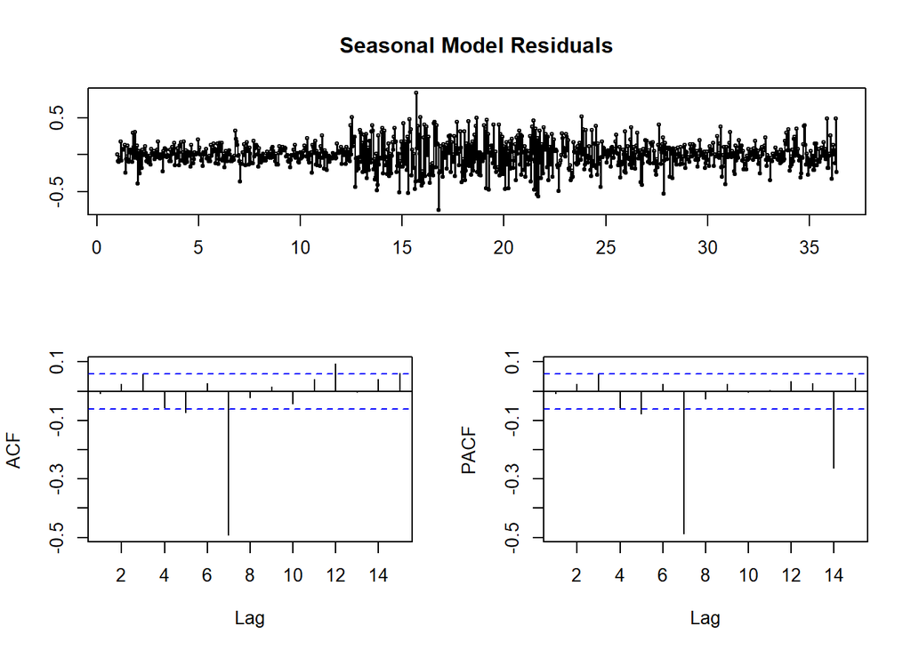

```r
fit5 <- arima(deseasonal_cnt, order=c(1,1,1))
tsdisplay(residuals(fit5), lag.max=15, main = "Seasonal Model Residuals")
```

Final fit and testing of the ARIMA forecast

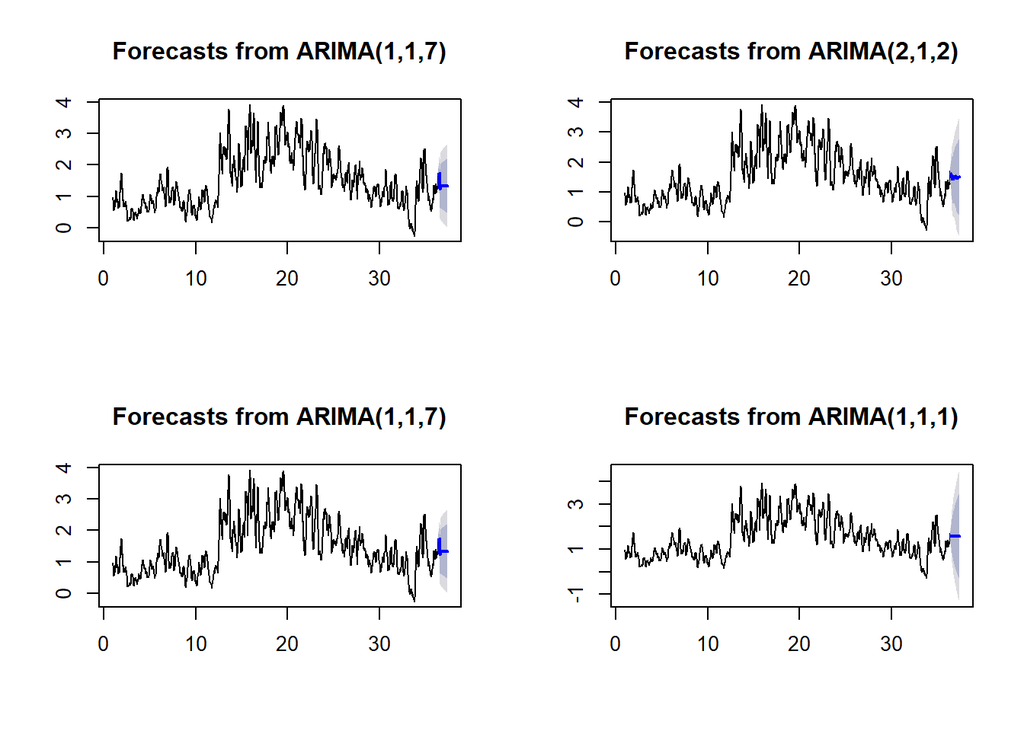

```r
par(mfrow=c(2,2))

# auto arima (2,0,3) fit with seasonality
facst <- forecast(fit_w_seasonality, h=30)
plot(fcast)

# auto arima (2,0,3) fit without seasonality
fcast2 <- forecast(fit3, h=30)
plot(fcast2)

# custom arima (1,1,7) fit
fcast3 <- forecast(fit4, h=30)
plot(fcast3)

# general default arima (1,1,1) fit
fcast4 <- forecast(fit5, h=30)
plot(fcast4)
```

### Sources

back to top

ARIMA modelling in R: https://otexts.com/fpp2/arima-r.html  
A Complete Tutorial on Time Series Modeling in R: https://www.analyticsvidhya.com/blog/2015/12/complete-tutorial-time-series-modeling/  
ARIMA Forecasting in R Part 1 - Exploratory Data Analysis: https://www.youtube.com/watch?v=UekOBfpu8m8  
ARIMA Forecasting in R Part 2 - Decomposition of the Data: https://www.youtube.com/watch?v=-qVAeU-_t_4  
ARIMA Forecasting in R Part 3 - Autocorrelations and Choosing the Model Order: https://www.youtube.com/watch?v=qqAyMwYEIaA  
ARIMA Forecasting in R Part 4 - Fitting an ARIMA Model: https://www.youtube.com/watch?v=GpO89Hx088o  
ARIMA Forecasting in R Part 5 - Testing the ARIMA Model with a Holdout Set and Seasonality: https://www.youtube.com/watch?v=3I_NrpWsVWM  
ARIMA Forecasting in R Part 6 - Further Testing and Final Model Selection and Visualization: https://www.youtube.com/watch?v=k6aiuu9oiTY  
Applied Time Series Analysis for Fisheries and Environmental Sciences: https://nwfsc-timeseries.github.io/atsa-labs/  
Introduction to Forecasting with ARIMA in R: https://www.datascience.com/blog/introduction-to-forecasting-with-arima-in-r-learn-data-science-tutorials